# **Practical Part**

### Mohammad Reza Nemati - 810100226

## **Hidden Markov Model**

### Summery:

This project aims to develop a classification system using Hidden Markov Models (HMMs) to recognize both the spoken digits and the speakers from audio recordings. Hidden Markov Models are powerful probabilistic models widely used in speech and pattern recognition tasks due to their ability to model sequential data effectively.

```python
from python_speech_features import mfcc as MFCC
import matplotlib.pyplot as plt
import glob
import numpy as np
import librosa
from hmmlearn import hmm
from sklearn.model_selection import train_test_split
from scipy.stats import multivariate_normal
```

These are the labels of the dataset.

```python
DIGITS = [
    'zero',
    'one',
    'two',
    'three',
    'four',
    'five',
    'six',
    'seven',
    'eight',
    'nine'
]

SPEAKERS = ['george', 'jackson', 'lucas', 'nicolas', 'theo', 'yweweler']
```

## Preprocess and Data Extraction:

### Question 1:

##### Segmentation: Good or Bad

In this project, segmentation was not employed in the preprocessing stage, and the classification results remained satisfactory.

1. **Homogeneous Data Structure**: The dataset consists of audio recordings from six speakers, with each speaker saying the same digit 50 times. This results in a homogeneous data structure where each recording contains consistent and repetitive patterns corresponding to the spoken digit. Therefore, there is minimal variability within each recording, making segmentation less critical for extracting relevant features.
2. **Continuous Speech**: The nature of the audio recordings, which involve continuous speech of the same digit by each speaker, facilitates feature extraction without the need for segmentation. Since the recordings are relatively short and contain coherent speech segments, MFCC extraction can effectively capture the spectral characteristics and temporal dynamics of the audio signals without segmenting them into smaller units.

### Question 2:

##### Features in Audio Signal Processing

1. **Mel-Spectrogram**:
   - The Mel-Spectrogram is a representation of the short-time Fourier transform of an audio signal, where the frequency axis is converted into the Mel scale, which better approximates human auditory perception.
   - Mel-Spectrogram captures both the frequency and time-domain characteristics of the audio signal and is commonly used in tasks such as speech recognition and music analysis.
2. **Zero Crossing Rate (ZCR)**:
   - Zero Crossing Rate is a simple feature that measures the rate at which the audio signal changes its sign.
   - It provides information about the temporal dynamics and the amount of variation in the audio signal.
   - ZCR is often used as a feature for detecting the presence of voiced speech or percussive sounds in audio signals.
3. **MFCC (Mel-Frequency Cepstral Coefficients)**:
   - MFCCs are a popular feature representation for audio signals, particularly in speech and audio processing tasks.
   - They capture the spectral envelope of the audio signal by representing it in the frequency domain using a set of coefficients derived from the Mel-Spectrogram.
   - MFCCs are computed by taking the Discrete Cosine Transform (DCT) of the log-filterbank energies obtained from the Mel-Spectrogram.
   - They are widely used for tasks such as speech recognition, speaker identification, and music genre classification.
4. **Chroma Features**:
   - Chroma features represent the distribution of energy in different pitch classes over time.
   - They are derived from the Fourier transform of the audio signal and are often computed after transforming the audio signal into a chromagram, where each bin corresponds to a specific pitch class.
   - Chroma features are useful for tasks involving music analysis, such as chord recognition, key estimation, and music genre classification.

##### Relationship between Features

- **Mel-Spectrogram and MFCCs**:
  - MFCCs are derived from the Mel-Spectrogram and capture the spectral characteristics of the audio signal in a compact representation.
  - The Mel-Spectrogram provides a time-frequency representation of the audio signal, while MFCCs further compress this information into a small number of coefficients by taking the DCT of the log-filterbank energies.
- **ZCR and MFCCs**:
  - ZCR provides information about the temporal dynamics of the audio signal, while MFCCs capture its spectral characteristics.
- **Chroma Features and MFCCs**:
  - Chroma features focus on the tonal content and harmonic structure of the audio signal, while MFCCs capture its overall spectral characteristics. These features can provide complementary information about the content of the audio signal.

### Implementing MFCCs

```python
def get_audios(recordings):
    audios = []
    for audio_file in recordings:
        audio, sampling_rate = librosa.load(audio_file, sr=None)
        audio, _ = librosa.effects.trim(audio, top_db=50, frame_length=1024)
        audios.append(audio)
    return audios, sampling_rate

def get_mfccs(audios, sampling_rate):
    mfccs = []
    max_frames = 33
    for audio in audios:
        mfcc = MFCC(audio, samplerate=sampling_rate, nfft=1024, numcep=12, winlen=0.05)
        if len(mfcc) < max_frames:
            mfcc_padded = np.pad(mfcc, ((0, max_frames - len(mfcc)), (0, 0)), mode='edge')
            mfccs.append(mfcc_padded)
        else:
            mfcc_truncated = mfcc[:max_frames, :]
            mfccs.append(mfcc_truncated)

    return mfccs

def plot_mfcc(recordings, mfccs_list):
    person = np.random.randint(0, len(recordings))
    num, name, index = recordings[person].split('\\')[-1].split('.')[0].split('_')
    plt.matshow(mfccs_list[int(index)].T, cmap='Spectral', origin='lower', aspect='auto')
    plt.title(f" digit {num} from {name} file {index} -- Mfcc heatmap")
    plt.ylabel('MFCC Coefficients')
    plt.xlabel('Time')
    plt.colorbar()
    plt.show()
```

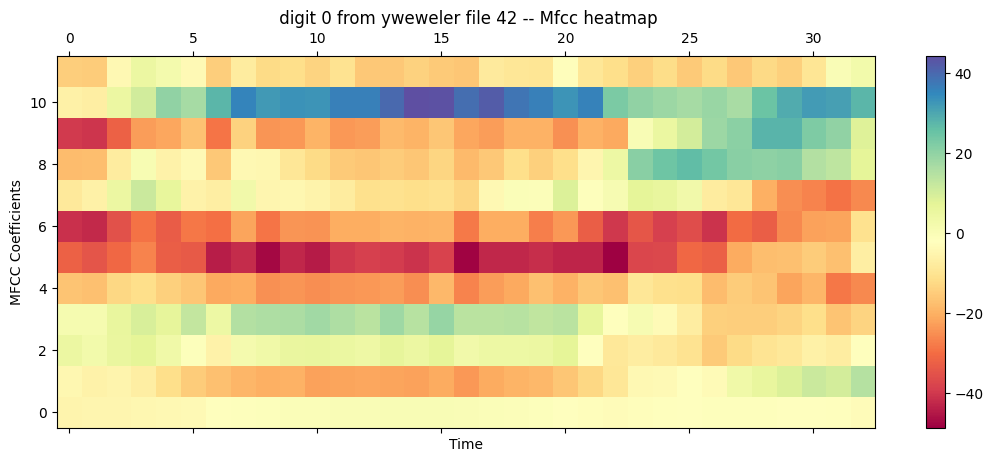

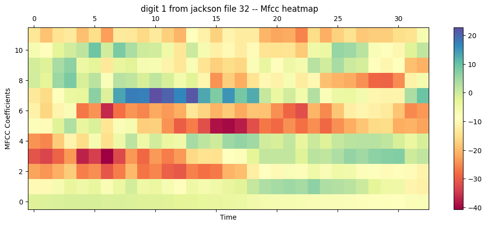

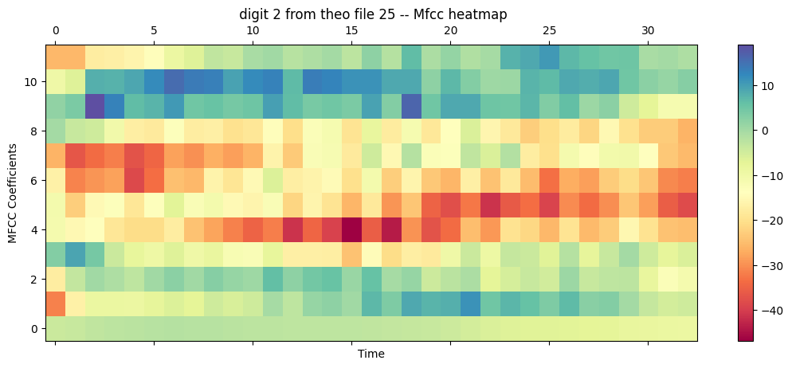

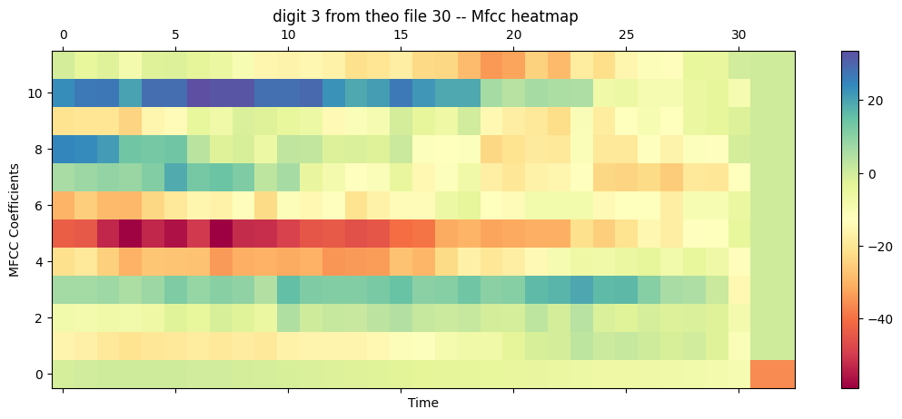

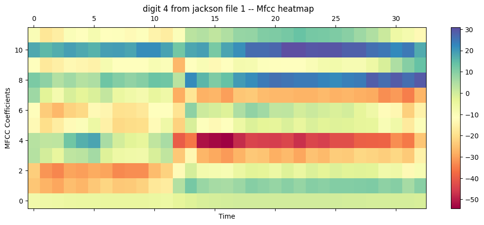

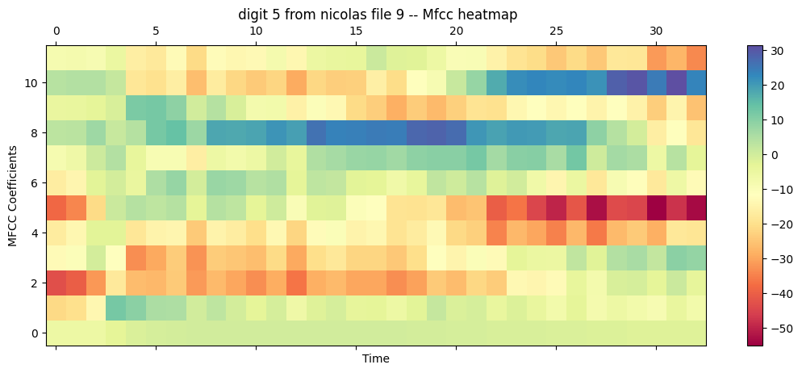

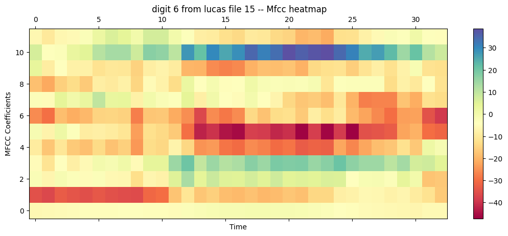

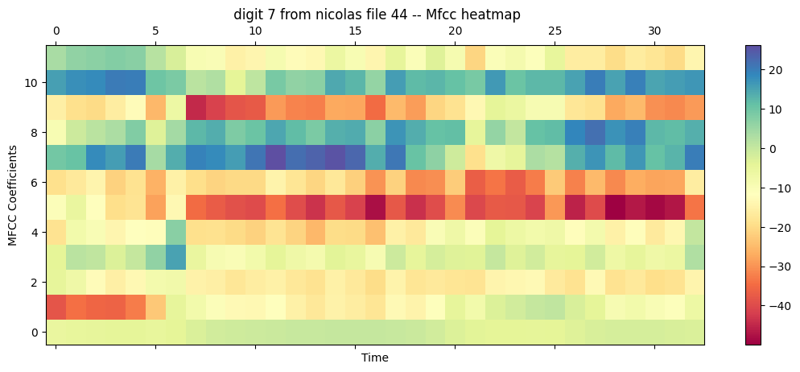

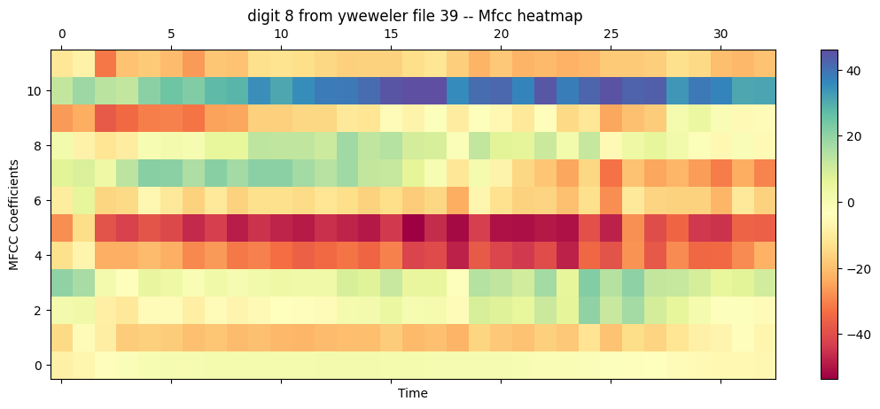

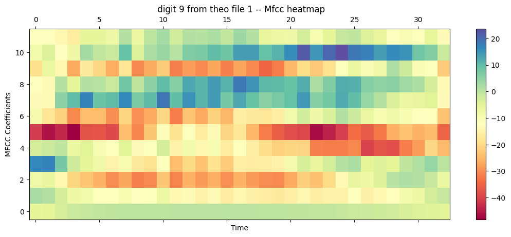

```python
all_recordings = glob.glob("./data/recordings/*.wav")

all_features_digit = []
total_nums_digit = []
for i in range(10):
    digit_recordings = [recording for recording in all_recordings if recording.startswith(f"./data/recordings\\{i}_")]
    audios, sampling_rate = get_audios(digit_recordings)
    mfccs = get_mfccs(audios, sampling_rate)
    plot_mfcc(digit_recordings, mfccs)
    all_features_digit.append(mfccs)
    total_nums_digit.append([i] * len(mfccs))


all_features_speaker = []
total_nums_speaker = []
for i in range(6):
    speaker_recordings = [recording for recording in all_recordings if SPEAKERS[i] in recording]
    audios, sampling_rate = get_audios(speaker_recordings)
    mfccs = get_mfccs(audios, sampling_rate)
    # plot_mfcc(speaker_recordings, mfccs)
    all_features_speaker.append(mfccs)
    total_nums_speaker.append([i] * len(mfccs))
```

### Question 3:

##### Robustness and Sensitivity of MFCCs

- **Noise Robustness**: MFCCs are robust to background noise and interference due to their logarithmic spectrum calculation, which emphasizes relevant spectral features while attenuating noise.
- **Temporal Robustness**: MFCCs capture short and long-term spectral characteristics, making them suitable for signals with temporal variations.
- **Frequency Sensitivity**: MFCCs accurately capture frequency content changes critical for human perception, such as pitch and formants.
- **Dynamic Sensitivity**: MFCCs detect dynamic spectral changes, providing insights into sound production and perception dynamics.
- **Parameter Sensitivity**: The effectiveness of MFCCs depends on parameter settings, including filterbanks, window size, and cepstral coefficients.

### Question 4:

##### MFCCs Less Effective Performance Cases:

1. **Non-Stationary Signals**: MFCCs assume that the audio signal is stationary within short analysis frames. However, in the presence of rapidly changing or non-stationary signals, such as those containing rapid pitch variations or transient sounds, MFCCs may fail to capture the dynamic spectral characteristics accurately.
2. **Nonlinear Distortions**: MFCC computation relies on linear operations such as the Discrete Fourier Transform (DFT) and Discrete Cosine Transform (DCT). In cases where the signal undergoes nonlinear distortions, such as clipping, saturation, or compression artifacts, MFCCs may not adequately represent the distorted spectral content.
3. **Limited Frequency Resolution**: MFCCs rely on a fixed number of Mel filterbanks to approximate the human auditory system's frequency resolution. In scenarios where fine frequency details or high-frequency components are crucial for discrimination, such as distinguishing between similar phonemes or identifying musical instruments, the limited frequency resolution of MFCCs may lead to suboptimal performance.
4. **Limited Discriminative Power**: While MFCCs capture essential spectral features, they may not fully capture all discriminative information present in the audio signal. In tasks requiring fine-grained discrimination between similar sounds or complex audio patterns, such as detecting subtle variations in speech or identifying specific musical genres, additional feature representations or more advanced feature extraction techniques may be necessary to achieve optimal performance.

### Question 5:

##### Overlapping frames in calculating Mel-Frequency Cepstral Coefficients (MFCCs)

1. Capture temporal dynamics.
2. Improve robustness to variability.
3. Smooth out short-term fluctuations.
4. Increase feature resolution.

These benefits enhance the effectiveness of MFCCs in representing the spectral characteristics of audio signals.

### Question 6:

##### Importance of the first 12 or 13 coefficients of MFCCs

In most projects, only the first 12 or 13 coefficients of MFCCs are used because they contain the most crucial information about the audio signal's spectral characteristics. Using fewer coefficients reduces dimensionality, improves computational efficiency, and aligns with historical and usual conventions in audio processing. These coefficients are perceptually relevant and computationally efficient and strike a balance between these factors, making them effective for various tasks such as speech recognition and audio classification.

## Introduction to HMM

### Question 1:

##### States and Observations

- **States**: In HMM, states represent the underlying, unobservable system that transitions over time. Each state corresponds to a certain situation or condition of the system. Transitions between states are governed by probabilities. The states doesn't necessarily mean anything and their number is just a hyperparameter of the model which describes its complexity.
- **Observations**: Observations are the visible outputs or measurements that are associated with each state. These are the data points that can be directly observed.

In the context of digit or speaker classification using HMM, the states might represent different sound or tone characteristics or accent, and observations are the features extracted from the audio data, such as MFCC coefficients in this project.

### Question 2:

##### First-Order HMM

The term `First-Order HMM` refers to a Hidden Markov Model where transitions between hidden states form a first-order Markov chain. This means that the probability of transitioning to a state depends only on the current state.

Features of a First-Order HMM:

- State transitions follow a first-order Markov process.
- Observations are emitted probabilistically based on the current state.
- Model parameters include initial state probabilities, transition probabilities, and emission probabilities.

Differences with other models:

- Higher-Order HMMs allow transitions dependent on multiple previous states.
- Continuous HMMs model continuous observations using probability distributions.
- Variable-Length HMMs accommodate irregular observation timing.

### Question 3:

##### Common Usages of HMMs Model

HMMs are particularly suitable for tasks involving sequential data with underlying patterns. They are commonly employed in:

1. **Speech Recognition**: In speech recognition, HMMs help decode spoken words by modeling the probabilistic relationships between phonemes and acoustic features. They enable systems to understand and transcribe spoken language accurately.
2. **Gesture Recognition**: HMMs are employed in gesture recognition systems to interpret and classify human gestures captured from sensors or cameras. By capturing the temporal dynamics of gestures, HMMs enable applications such as sign language recognition, human-computer interaction, and motion-based gaming.
3. **Financial Analysis**: HMMs are applied in financial analysis to model and predict market trends in time-series data, such as stock prices, market indices, and economic indicators. By identifying different market regimes or states, HMMs assist in risk management, portfolio optimization, algorithmic trading, and financial forecasting.
4. **Natural Language Processing (NLP)**: In NLP, HMMs are used for various tasks such as part-of-speech tagging, named entity recognition, and machine translation. They model the sequential nature of language by capturing transitions between words or linguistic elements, enabling applications such as text summarization, sentiment analysis, and information retrieval.

### Question 4:

##### Pros and Cons of HMM

**Pros:**

1. **Versatility**: HMMs are adaptable to various sequential data types, from speech signals to genetic sequences.
2. **Probabilistic Framework**: HMMs handle uncertainty well, making them robust in noisy environments.
3. **State Interpretability**: Hidden states often have clear interpretations, aiding in understanding underlying processes.
4. **Efficient Inference**: Algorithms like Viterbi and Forward-Backward make state and parameter estimation computationally feasible.

**Cons:**

1. **Assumption of Stationarity**: HMMs assume stationary processes, which may not hold in dynamic environments.
2. **Curse of Dimensionality**: Model complexity grows rapidly with the number of states or observations, leading to computational challenges.
3. **Sensitivity to Parameters**: Performance can be affected by parameter choices, requiring careful tuning.
4. **Limited Memory**: HMMs struggle to capture long-term dependencies in sequences.
5. **Training Difficulty**: Training may be computationally intensive and prone to convergence issues, especially with complex models or high-dimensional data.

### Question 5:

##### Other Forms of HMM Models

1. **Higher-Order HMMs**: These models relax the first-order Markov assumption by allowing transitions that depend on multiple previous states. This enables them to capture more complex dependencies in sequential data but comes at the cost of increased computational complexity and model parameters.
2. **Continuous HMMs (CHMMs)**: In CHMMs, observations are continuous rather than discrete, and emission probabilities are modeled using continuous probability distributions such as Gaussian distributions.
3. **Variable-Length HMMs**: Variable-Length HMMs relax the assumption that observations are generated at regular intervals, allowing for sequences of varying lengths. This is useful in applications where the timing of observations is irregular or unpredictable, such as speech recognition with variable-length utterances.
4. **Hidden Semi-Markov Models (HSMMs)**: HSMMs extend HMMs by allowing for variable-duration states, where the duration of each state is drawn from a distribution rather than being fixed. This enables them to model temporal patterns with variable lengths more effectively, making them suitable for tasks such as activity recognition or speech segmentation.
5. **Factorial HMMs (FHMMs)**: FHMMs are a type of structured HMM where multiple independent HMMs are combined into a single model. Each component HMM captures different aspects or modalities of the data, allowing for more flexible modeling of complex data structures.

## Implementing HMM Using `hmmlearn` Library

```python
def get_dataset(data, labels, components):
    DS_train = {}
    data_test_x = []
    data_test_y = []

    for i in range(len(components)):
        x_train, x_test, y_train, y_test = train_test_split(np.array(data[i]), np.array(labels[i]),
                                                            test_size=0.2, random_state=42)
        DS_train[i] = x_train.reshape((-1, x_train.shape[2]))
        data_test_x.extend(x_test)
        data_test_y.extend(y_test)

    data_test_x = np.array(data_test_x)
    data_test_y = np.array(data_test_y)

    return DS_train, data_test_x, data_test_y

def learn_models_with_library(DS_train, components, num_states):
    models = []
    for i in range(len(components)):
        model = hmm.GaussianHMM(n_components=num_states, covariance_type='tied')
        model.fit(DS_train[i])
        models.append(model)

    return models

def get_preds(models, x_test):
    scores = np.array([[model.score(x_test[i, :]) for model in models] for i in range(x_test.shape[0])])
    preds = np.argmax(scores, axis=1)
    return preds.tolist()

def calc_accuracy(y_test, y_pred):
    total_samples = len(y_test)
    correct_predictions = sum(1 for true_label, pred_label in zip(y_test, y_pred) if true_label == pred_label)
    accuracy = correct_predictions / total_samples

    return accuracy

def calc_precision(y_test, y_pred, num_classes):
    precision_per_class = [0] * num_classes
    for true_label in range(num_classes):
        true_positives = sum(1 for true, pred in zip(y_test, y_pred) if true == true_label and pred == true_label)
        total_predicted = sum(1 for pred in y_pred if pred == true_label)
        if total_predicted == 0:
            precision_per_class[true_label] = 0
        else:
            precision_per_class[true_label] = true_positives / total_predicted
    precision = sum(precision_per_class) / len(precision_per_class)

    return precision

def calc_confusion_matrix(true_labels, predicted_labels, num_classes):
    confusion_matrix = [[0] * num_classes for _ in range(num_classes)]
    class_totals = [sum(1 for label in true_labels if label == i) for i in range(num_classes)]

    for true_label, pred_label in zip(true_labels, predicted_labels):
        confusion_matrix[true_label][pred_label] += 1

    for i in range(num_classes):
        for j in range(num_classes):
            percentage = (confusion_matrix[i][j] / class_totals[i]) * 100 if class_totals[i] != 0 else 0
            confusion_matrix[i][j] = round(percentage, 2)

    return confusion_matrix

def plot_confusion_matrix(confusion_matrix, labels):
    num_classes = len(confusion_matrix)
    plt.figure(figsize=(8, 6))
    plt.imshow(confusion_matrix, interpolation='nearest', cmap=plt.cm.Blues)
    plt.title('Confusion Matrix')
    plt.colorbar()
    plt.xticks(np.arange(len(labels)), labels)
    plt.yticks(np.arange(len(labels)), labels)
    plt.ylabel('True Label')
    plt.xlabel('Predicted Label')
    for i in range(num_classes):
        for j in range(num_classes):
            plt.text(j, i, str(confusion_matrix[i][j]), horizontalalignment="center", color="white" if confusion_matrix[i][j] > (0.5 * confusion_matrix[i][i]) else "black")
    plt.show()

def calc_metrics(y_test, y_pred, components, name, comment=""):
    print(f"{name} Model {comment} Metrics:")
    print(f"\tAccuracy: {calc_accuracy(y_test, np.array(y_pred)):.4f}")
    print(f"\tPrecision: {calc_precision(y_test, np.array(y_pred), len(components)):.4f}")
```

```python
DS_train, data_test_x, data_test_y = get_dataset(all_features_digit, total_nums_digit, DIGITS)
digit_models = learn_models_with_library(DS_train, DIGITS, 10)

preds = get_preds(digit_models, data_test_x)
```

```
Digit Model Using Library Metrics:
	Accuracy: 0.9583
	Precision: 0.9583
```

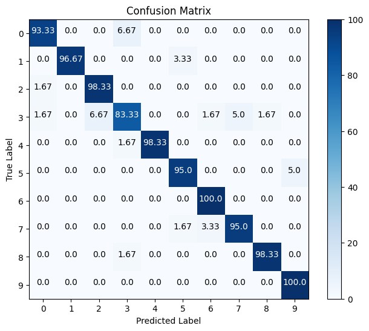

```python
accuracy = calc_accuracy(data_test_y, preds)
precision = calc_precision(data_test_y, preds, len(DIGITS))

conf_matrix = calc_confusion_matrix(data_test_y, preds, len(DIGITS))

calc_metrics(data_test_y, preds, DIGITS, "Digit", "Using Library")
plot_confusion_matrix(conf_matrix, range(0, 10))
```

```python
DS_train, data_test_x, data_test_y = get_dataset(all_features_speaker, total_nums_speaker, SPEAKERS)
person_models = learn_models_with_library(DS_train, SPEAKERS, 12)

preds = get_preds(person_models, data_test_x)
```

```
Speaker Model Using Library Metrics:
	Accuracy: 0.9667
	Precision: 0.9674
```

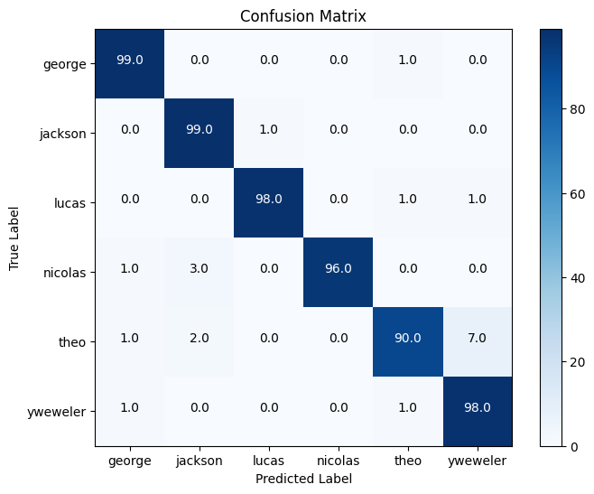

```python
accuracy = calc_accuracy(data_test_y, preds)
precision = calc_precision(data_test_y, preds, len(SPEAKERS))

conf_matrix = calc_confusion_matrix(data_test_y, preds, len(SPEAKERS))

calc_metrics(data_test_y, preds, SPEAKERS, "Speaker", "Using Library")
plot_confusion_matrix(conf_matrix, SPEAKERS)
```

## Implementing HMM From Scratch

```python
class HMM:
    def __init__(self, num_hidden_states):
        self.num_hidden_states = num_hidden_states
        self.rand_state = np.random.RandomState(1)

        self.initial_prob = self._normalize(self.rand_state.rand(self.num_hidden_states, 1))
        self.transition_matrix = self._stochasticize(self.rand_state.rand(self.num_hidden_states, self.num_hidden_states))

        self.mean = None
        self.covariances = None
        self.num_dimensions = None

    def _forward(self, observation_matrix):
        log_likelihood = 0.
        T = observation_matrix.shape[1]
        alpha = np.zeros(observation_matrix.shape)

        for t in range(T):
            if t == 0:
                alpha[:,0] =  self.initial_prob.flatten() * observation_matrix[:, t]
            else:
                alpha[:,t] = np.matmul(self.transition_matrix.T,alpha[:, t-1]) * observation_matrix[:, t]

            alpha_sum = np.sum(alpha[:, t])
            alpha[:, t] /= alpha_sum
            log_likelihood += np.log(alpha_sum)

        return log_likelihood, alpha

    def _backward(self, observation_matrix):
        T = observation_matrix.shape[1]
        beta = np.zeros(observation_matrix.shape)

        beta[:, -1] = np.ones(observation_matrix.shape[0])

        for t in range(T - 1)[::-1]:
            beta[:, t] = np.matmul(self.transition_matrix, (observation_matrix[:, t+1] * beta[:, t+1]))
            beta[:, t] /= np.sum(beta[:, t])

        return beta

    def _state_likelihood(self, obs):
        obs = np.atleast_2d(obs)
        B = np.zeros((self.num_hidden_states, obs.shape[1]))

        for s in range(self.num_hidden_states):
            np.random.seed(self.rand_state.randint(1))
            B[s, :] = multivariate_normal.pdf(obs.T, mean=self.mean[:, s], cov=self.covariances[:, :, s])

        return B

    def _normalize(self, x):
        return (x + (x == 0)) / np.sum(x)

    def _stochasticize(self, x):
        return (x + (x == 0)) / np.sum(x, axis=1)

    def _em_init(self, obs):
        if self.num_dimensions is None:
            self.num_dimensions = obs.shape[0]
        if self.mean is None:
            subset = self.rand_state.choice(np.arange(self.num_dimensions), size=self.num_hidden_states, replace=False)
            self.mean = obs[:, subset]
        if self.covariances is None:
            self.covariances = np.zeros((self.num_dimensions, self.num_dimensions, self.num_hidden_states))
            self.covariances += np.diag(np.diag(np.cov(obs)))[:, :, None]

        return self

    def _em_step(self, obs):
        obs = np.atleast_2d(obs)
        T = obs.shape[1]

        B = self._state_likelihood(obs=obs)

        log_likelihood, alpha = self._forward(B)
        beta = self._backward(B)

        xi_sum = np.zeros((self.num_hidden_states, self.num_hidden_states))
        gamma = np.zeros((self.num_hidden_states, T))

        for t in range(T - 1):
            partial_sum = sum(alpha[:, t] * beta[:, t+1] * B[:, t+1]) * self.transition_matrix
            xi_sum += self._normalize(partial_sum)
            partial_g = alpha[:,t] * beta[:, t]
            gamma[:, t] = self._normalize(partial_g)

        partial_g = alpha[:, T-1] * beta[:, T-1]
        gamma[:, -1] = self._normalize(partial_g)

        expected_prior = gamma[:,0]
        expected_transition = self._stochasticize(xi_sum/np.sum(xi_sum, axis=(0, 1)))

        expected_covariances = np.zeros((self.num_dimensions, self.num_dimensions, self.num_hidden_states))
        expected_covariances += .01 * np.eye(self.num_dimensions)[:, :, None]

        gamma_state_sum = np.sum(gamma, axis=1)
        gamma_state_sum = gamma_state_sum + (gamma_state_sum == 0)

        expected_mean = np.zeros((self.num_dimensions, self.num_hidden_states))
        for s in range(self.num_hidden_states):
            gamma_obs = obs * gamma[s, :]
            expected_mean[:, s] = np.sum(gamma_obs, axis=1) / gamma_state_sum[s]

        self.initial_prob = expected_prior
        self.mean = expected_mean
        self.covariances = expected_covariances
        self.transition_matrix = expected_transition

        return log_likelihood

    def train(self, obs, num_iterations=1):
        for i in range(num_iterations):
            self._em_init(obs)
            self._em_step(obs)
        return self

    def score(self, obs):
        B = self._state_likelihood(obs)
        log_likelihood, _ = self._forward(B)
        return log_likelihood
```

```python
def learn_models_from_scratch(DS_train, components, num_states):
    models = []
    for i in range(len(components)):
        model = HMM(num_hidden_states=num_states)
        model.train(DS_train[i].T / np.amax(DS_train[i].T), num_iterations=10)
        models.append(model)

    return models

def get_preds_scratch(models, data_test_x):
    preds = [np.argmax([model.score(data.T / np.amax(data.T)) for model in models]) for data in data_test_x]
    return preds
```

```python
DS_train, data_test_x, data_test_y = get_dataset(all_features_digit, total_nums_digit, DIGITS)
scratch_models = learn_models_from_scratch(DS_train, DIGITS, 10)

preds = get_preds_scratch(scratch_models, data_test_x)
```

```
Digit Model From Scratch Metrics:
	Accuracy: 0.8033
	Precision: 0.8547
```

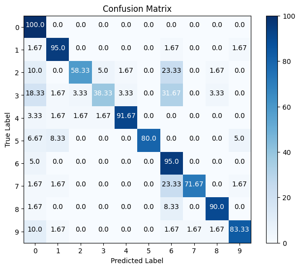

```python
accuracy = calc_accuracy(data_test_y, preds)
precision = calc_precision(data_test_y, preds, len(DIGITS))

conf_matrix = calc_confusion_matrix(data_test_y, preds, len(DIGITS))

calc_metrics(data_test_y, preds, DIGITS, "Digit", "From Scratch")
plot_confusion_matrix(conf_matrix, range(0, 10))
```

```python
DS_train, data_test_x, data_test_y = get_dataset(all_features_speaker, total_nums_speaker, SPEAKERS)
scratch_models = learn_models_from_scratch(DS_train, SPEAKERS, 7)

preds = get_preds_scratch(scratch_models, data_test_x)
```

```
Speaker Model From Scratch Metrics:
	Accuracy: 0.7900
	Precision: 0.8279
```

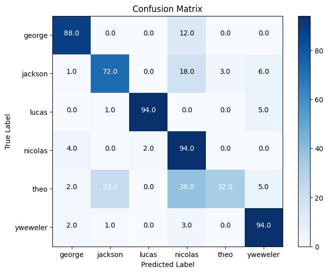

```python
accuracy = calc_accuracy(data_test_y, preds)
precision = calc_precision(data_test_y, preds, len(SPEAKERS))

conf_matrix = calc_confusion_matrix(data_test_y, preds, len(SPEAKERS))

calc_metrics(data_test_y, preds, SPEAKERS, "Speaker", "From Scratch")
plot_confusion_matrix(conf_matrix, SPEAKERS)
```

## Library and From-Scratch differences

Models accuracy and precision, with `hhmlearn` library implementation are above 90 percent. But `Hmm Class` models, its metrics are about 80 percent.

## Result Evaluation

### Question 1:

##### Different Metrics For Learning Models: Formula

These are the formulas:

- Accuracy: $$\ \text{Accuracy} = \frac{\text{Number of Correct Predictions}}{\text{Total Number of Predictions}} =\frac{\text{True Positive} + \text{True Negative}}{\text{True Positive} + \text{True Negative} + \text{False Positive} + \text{False Negative}} $$
- Precision: $$ \text{Precision} = \frac{\text{True Positives}}{\text{True Positives + False Positives}} $$
- Recall: $$ \text{Recall} = \frac{\text{True Positives}}{\text{True Positives + False Negatives}} $$
- F1 Score $$ \text{F1 Score} = \frac{2 \times (\text{Precision} \times \text{Recall})}{\text{Precision} + \text{Recall}} $$

### Question 2:

##### Calculating Multi-Class Model Metrics Challenges

Calculating metrics like accuracy, precision, recall, and F1 score for a multi-class classification model is indeed more complex than for a binary classification model. However, there are some methods to overcome these challenges:

1. **Confusion Matrix**: Construct a confusion matrix, which is a tabulation of the number of correctly and incorrectly classified instances for each class. From the confusion matrix, we can derive metrics like accuracy, precision, recall, and F1 score for each class. This method was used in this project.
2. **One-vs-All (OvA) Strategy**: In this approach, we treat each class as the positive class while treating all other classes as the negative class. We then calculate precision, recall, and F1 score for each class individually. Finally, we can aggregate the results across all classes using methods like other averaging methods.
3. **Other Averaging Methods**: There are several other averaging methods such as `Macro-Averaging`, `Micro-Averaging` and `Weighted Averaging`. We will explore each in the next questions.

By using these strategies, we can effectively evaluate the performance of multi-class classification models and gain insights into how well they perform across different classes.

### Question 3:

##### Different Metrics For Learning Models: Explaination

- **Accuracy**: It is a straightforward measure that indicates the proportion of correctly classified instances out of the total number of instances. While it offers a quick overview of a model's performance, it can be misleading in scenarios where classes are imbalanced. For instance, in a dataset where one class significantly outnumbers the others, a model may achieve high accuracy by simply predicting the majority class for all instances, without effectively capturing the minority classes.
- **Precision**: Precision delves deeper into the correctness of positive predictions. It calculates the ratio of true positives to all instances predicted as positive, emphasizing the model's ability to avoid false positives. High precision indicates that the model makes few incorrect positive predictions relative to the total number of positive predictions.
- **Recall**: Recall, also known as sensitivity or true positive rate, measures the model's ability to capture all positive instances. It calculates the ratio of true positives to all actual positive instances, emphasizing the model's capability to avoid false negatives. High recall implies that the model successfully identifies most positive instances among all instances in the positive class.
- **F1 Score**: F1 Score serves as a balance between precision and recall, combining them into a single metric. It represents the harmonic mean of precision and recall, providing an overall assessment of the model's performance. The F1 score is particularly useful when there is an uneven trade-off between precision and recall, ensuring that both false positives and false negatives are considered in the evaluation.

### Question 4:

##### Precision vs. Recall: Differences and Flaws

- **Precision**: Precision measures the proportion of correctly predicted positive instances among all instances predicted as positive. It emphasizes the correctness of positive predictions and is calculated as the ratio of true positives to the sum of true positives and false positives. High precision indicates that the model makes few incorrect positive predictions relative to the total number of positive predictions.
- **Recall**: Recall, also known as sensitivity or true positive rate, measures the proportion of correctly predicted positive instances among all actual positive instances. It emphasizes the model's ability to capture all positive instances and is calculated as the ratio of true positives to the sum of true positives and false negatives. High recall implies that the model successfully identifies most positive instances among all instances in the positive class.

Precision and recall are not always sufficient on their own to evaluate the model comprehensively. This is because a model can achieve high precision or recall while still performing poorly overall.

For example:

- **High Precision, Low Recall**: Suppose a spam detection model has high precision but low recall. This means that when it predicts an email as spam, it is usually correct (high precision), but it misses many actual spam emails (low recall). As a result, the model may incorrectly classify a significant number of legitimate emails as spam, leading to a poor overall user experience.
- **High Recall, Low Precision**: Suppose a medical diagnostic model that has high recall but low precision. This means that it correctly identifies most instances of a disease (high recall), but it also generates many false positive diagnoses (low precision). As a result, the model may subject patients to unnecessary tests or treatments, leading to unnecessary costs and potential harm.

### Question 5:

##### F1 Score Averaging Method

The F1 score uses `harmonic mean` averaging method. Unlike normal averaging methods, the harmonic mean gives more weight to lower values. This ensures that the F1 score penalizes models with large disparities between precision and recall, providing a balanced evaluation of the model's performance. By capturing the balance between precision and recall, the F1 score offers a single metric that reflects the model's effectiveness across various scenarios, making it valuable in model evaluation.

### Questions 6-7:

##### Training The Model

`target var = digitLabal`

We can see that the accuracy and precision of the model based on the Digit are above 90% (*library based*) and 80% (*from scratch*) which shows that the model can classify the test data with good performance.

Throught project with running the model multiple times, it was observed that the most difficult digit to label was `3`. Most of the times, its model's accuracy and precision was less than the others. We can clearly see this in the scratch version. Also `0` and `9` models often had good performance.

### Question 8:

##### Differences in Target Variable

One of the reasons for not stable answer can be related to the randomess of the models, and as the differences are very small (like 2 or 3%), we can say that the our models based on the targets work pretty well and close to eachother.